# H.murinum CpG NCBI

Andrés Delgado

2025-09-12

## PREPROCESSING

#### Brevemente resumo los pasos previos al análisis:

1. Se utilizó como genoma de referencia el ensamblaje ASM2249601v1 (Hordeum marinum, GCA_022496015.1), descargado de NCBI Genome el [02/09/2025] en el siguiente enlace: https://www.ncbi.nlm.nih.gov/datasets/genome/GCA_022496015.1/
2. Alineamiento de las lecturas de bisulfito de mis muestras tratadas con el genoma de referencia usando BISMARK en linux.
3. Generación de informes de metilación de las muestras asociados a sus posiciones en el genoma de referencia. BISMARK genera estos informes en forma de archivos .bam
4. Importación de los archivos .bam a methylkit para el análisis

## DIFFERENTIAL METHYLATION ANALYSIS

Con la función “pairwise_diff()” de methylKit, podemos comparar la población de cada tratamiento con la población control (en este caso el control es Grazed+Unclipped). Obtenemos hipo- e hiper- metilaciones con respecto al control, y cada una de estas diferencias está asociada a un p-valor. En este caso hemos considerado como Differentially Methylated Points (**DMPs**) cuando la **diferencia de metilación > 10%** y el **p-valor < 0.05**

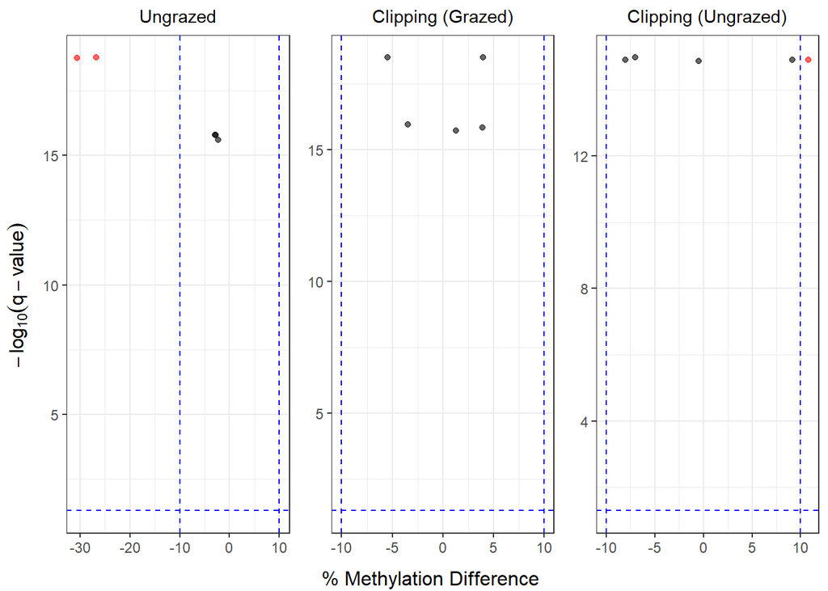

Differentially methylated sites

| Condition | Ungrazed | Clipped | Ungrazed…Clipped |
| --- | --- | --- | --- |
| Hypermethylated | 0 | 0 | 1 |
| Hypomethylated | 2 | 0 | 0 |